# 数据清洗0923

goatbishop

2020年9月23日

### 导包

```r
library(VIM)
library(mice)
library(readr)
library(psych)
library(fpc)
library(lattice)
library(MASS)
```

### 自定义函数

```r
#统计行/列 缺失值函数
countNaN <- function(myline) {
  return(sum(is.na(myline)))
}

#定位函数
#dataF只能传递矩阵或者数据框
myPosition <- function(dataF, flag = T) {
  posmtr <- matrix(0, ncol = 2)
  colnames(posmtr) <- c("rowNum", "colNum")
  numberCol <- dim(dataF)[2]
  numberRow <- dim(dataF)[1]
  for (item in c(1:numberCol)) {
    targetIndex <- which(dataF[, item])
    lenTar <- length(targetIndex)
    tempMatrix <- data.frame(rowNum = targetIndex, colNum = rep(item, lenTar))
    posmtr <- rbind(posmtr, tempMatrix)
  }
  posmtr <- posmtr[-1, ]
  return(posmtr)
}

#回归函数

myregression <- function(vectorX, vectorY, newX) {
  print(vectorX)
  print(vectorY)
  lmtemp <- lm(vectorY ~ vectorX)
  print(lmtemp$coef)
  pre <- predict(lmtemp, data.frame(vectorX = newX))
  newY <- pre
  return(newY)
}
```

### 读取数据

```r
mydata <- read.csv("../RawData0923.csv")


dim(mydata) #1100 24
```

```
## [1] 1100   24
```

```r
head(mydata)
```

```
##     city year realGdpPerCapita gdpGrowthRate InvestOutputRate proSocLab
## 1   上海 2018           134982           6.6         4.509683  510092.4
## 2 南京市 2018           152886           8.0         1.895909  584988.9
## 3 无锡市 2018           174270           7.4         4.316703 1018379.3
## 4 徐州市 2018            76915           4.2         2.619712  773282.1
## 5 常州市 2018           149277           7.0         2.013545 1031911.9
## 6 苏州市 2018           173765           6.8         7.167812  641015.1
##   pro2industryGdp pro3industryGdp advIndexIndusStruc ratIndexIndusStruc
## 1           29.78           69.90           2.347213        0.000510047
## 2           36.83           61.04           1.657345        0.113456809
## 3           47.77           51.14           1.070546        0.084413909
## 4           41.63           49.03           1.177756        0.107350595
## 5           46.29           51.50           1.112551            #DIV/0!
## 6           48.03           50.81           1.057880        0.168248122
##   nonAgriDevDegree incomeRatUrbanRural    urbanRat regUrbanUnemployRat
```

[output cut: 27 more lines]

```r
#str(mydata)
```

可以看到共有1100条数据,共有110个城市,十年的数据,且原本应该为数值型的变量，却显示为字符型，说明数据中可能存在字符型数据。

### 整理数据

将数据中有#DIV/0!和0的设置为缺失值

```r
mydata2 <- mydata

for (item in c(2:length(mydata2))) {
  data_type <- class(mydata2[, item])
  if (data_type == "character") {
    temp_dataL <- mydata2[, item]
    temp_dataL[which(temp_dataL == "#DIV/0!")] = NA
    #第二次修改后增加
    temp_dataL[which(temp_dataL == 0)] = NA
    mydata2[, item] <- as.numeric(temp_dataL)
  }
}

str(mydata)
```

```
## 'data.frame':    1100 obs. of  24 variables:
##  $ city               : chr  "上海" "南京市" "无锡市" "徐州市" ...
##  $ year               : int  2018 2018 2018 2018 2018 2018 2018 2018 2018 2018 ...
##  $ realGdpPerCapita   : num  134982 152886 174270 76915 149277 ...
##  $ gdpGrowthRate      : num  6.6 8 7.4 4.2 7 6.8 7.2 4.7 6.5 5.5 ...
##  $ InvestOutputRate   : num  4.51 1.9 4.32 2.62 2.01 ...
##  $ proSocLab          : num  510092 584989 1018379 773282 1031912 ...
##  $ pro2industryGdp    : num  29.8 36.8 47.8 41.6 46.3 ...
##  $ pro3industryGdp    : num  69.9 61 51.1 49 51.5 ...
##  $ advIndexIndusStruc : num  2.35 1.66 1.07 1.18 1.11 ...
##  $ ratIndexIndusStruc : chr  "0.000510047" "0.113456809" "0.084413909" "0.107350595" ...
##  $ nonAgriDevDegree   : chr  "0.001645899" "-0.021252214" "-0.010790794" "-0.080558452" ...
##  $ incomeRatUrbanRural: chr  "2.239809868" "2.347623006" "1.851073505" "" ...
##  $ urbanRat           : chr  "86.4902507" "82.50041488" "76.27956499" "" ...
##  $ regUrbanUnemployRat: chr  "2.636983193" "1.25650115" "1.196692933" "1.818220079" ...
##  $ proTechEduExpendGdp: num  4.11 2.6 1.89 2.9 1.83 ...
##  $ amoforeCapUtil     : int  1730009 385339 369133 189848 242189 452498 258140 60345 118213 91313 ...
##  $ foreTradeCoef      : chr  "1.040699672" "0.332042292" "0.530995872" "" ...
##  $ numCollegeStu      : chr  "366.1090883" "1228.057862" "242.0594867" "131.239231" ...
##  $ PowConsumpPerGdpL  : chr  "0.047939588" "0.047299616" "0.030590229" "0.052114599" ...
##  $ dischaIndusWaste   : chr  "8.92E-05" "0.000121166" "0.000180284" "4.53E-05" ...
##  $ greenCoverRat      : num  39.4 45.1 43 44 43 41 44 41 42 43 ...
##  $ libCollect         : chr  "53994.52804" "10803.44333" "17162.97787" "3693.779904" ...
##  $ numHospBed         : chr  "88.24008208" "70.94404591" "79.96579477" "39.76363636" ...
##  $ socSecEmployExpend : num  NA 170 95.9 111.9 67.2 ...
```

```r
str(mydata2)
```

```
## 'data.frame':    1100 obs. of  24 variables:
##  $ city               : chr  "上海" "南京市" "无锡市" "徐州市" ...
##  $ year               : int  2018 2018 2018 2018 2018 2018 2018 2018 2018 2018 ...
##  $ realGdpPerCapita   : num  134982 152886 174270 76915 149277 ...
##  $ gdpGrowthRate      : num  6.6 8 7.4 4.2 7 6.8 7.2 4.7 6.5 5.5 ...
##  $ InvestOutputRate   : num  4.51 1.9 4.32 2.62 2.01 ...
##  $ proSocLab          : num  510092 584989 1018379 773282 1031912 ...
##  $ pro2industryGdp    : num  29.8 36.8 47.8 41.6 46.3 ...
##  $ pro3industryGdp    : num  69.9 61 51.1 49 51.5 ...
##  $ advIndexIndusStruc : num  2.35 1.66 1.07 1.18 1.11 ...
##  $ ratIndexIndusStruc : num  0.00051 0.11346 0.08441 0.10735 NA ...
##  $ nonAgriDevDegree   : num  0.00165 -0.02125 -0.01079 -0.08056 -0.0221 ...
##  $ incomeRatUrbanRural: num  2.24 2.35 1.85 NA 1.93 ...
##  $ urbanRat           : num  86.5 82.5 76.3 NA 72.5 ...
##  $ regUrbanUnemployRat: num  2.64 1.26 1.2 1.82 1.28 ...
##  $ proTechEduExpendGdp: num  4.11 2.6 1.89 2.9 1.83 ...
##  $ amoforeCapUtil     : int  1730009 385339 369133 189848 242189 452498 258140 60345 118213 91313 ...
##  $ foreTradeCoef      : num  1.041 0.332 0.531 NA 0.321 ...
##  $ numCollegeStu      : num  366 1228 242 131 349 ...
##  $ PowConsumpPerGdpL  : num  0.0479 0.0473 0.0306 0.0521 0.0561 ...
##  $ dischaIndusWaste   : num  8.92e-05 1.21e-04 1.80e-04 4.53e-05 1.76e-04 ...
##  $ greenCoverRat      : num  39.4 45.1 43 44 43 41 44 41 42 43 ...
##  $ libCollect         : num  53995 10803 17163 3694 13953 ...
##  $ numHospBed         : num  88.2 70.9 80 39.8 54.8 ...
##  $ socSecEmployExpend : num  NA 170 95.9 111.9 67.2 ...
```

查看整体的缺失值情况：

```r
length(which(complete.cases(mydata2))) #502
```

```
## [1] 502
```

可以看到总共有502个观测是完整的。

绘制缺失值图：

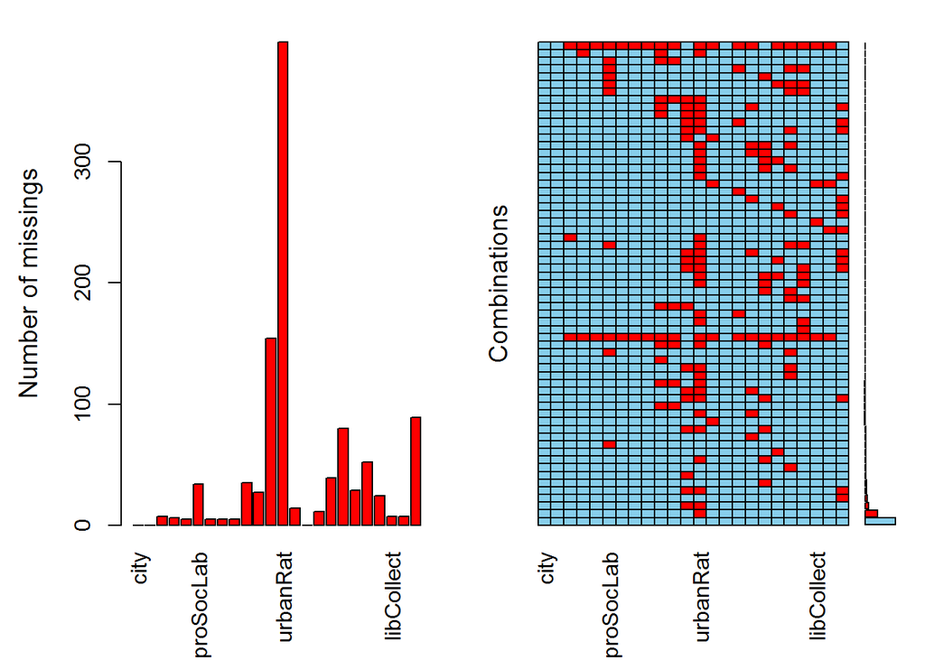

```r
#png("../images/缺失值图1.png")
aggr(mydata2, prop = F, numbers = T)
```

```r
#dev.off()
```

查看各个变量的缺失值情况:

```r
cNa <- apply(mydata2, 2, countNaN)
cNa[which(cNa > 0)]
```

```
##    realGdpPerCapita       gdpGrowthRate    InvestOutputRate           proSocLab
##                   7                   6                   5                  34
##     pro2industryGdp     pro3industryGdp  advIndexIndusStruc  ratIndexIndusStruc
##                   5                   5                   5                  35
##    nonAgriDevDegree incomeRatUrbanRural            urbanRat regUrbanUnemployRat
##                  27                 154                 399                  14
##      amoforeCapUtil       foreTradeCoef       numCollegeStu   PowConsumpPerGdpL
##                  11                  39                  80                  29
##    dischaIndusWaste       greenCoverRat          libCollect          numHospBed
##                  52                  24                   7                   7
##  socSecEmployExpend
##                  89
```

可以看到, 变量urbanRat缺失了399个数据, incomeRatUrbanRural缺失了154个数据, socSecEmployExpend缺失了89个数据, numCollegeStu缺失了80个数据.

### 考察变量间的相关性

```r
#剔除年份和城市两个无关变量再计算相关系数
testdata <- mydata2[, -c(1, 2)]
#只保留完整数据行进行相关性分析
comdata01 <- testdata[which(complete.cases(testdata)== T), ]
#有524条完整记录
dim(comdata01) #524  22
```

```
## [1] 502  22
```

```r
#计算相关系数
#cor(comdata01)

#相关系数大于0.6的返回True
outcor <- cor(comdata01) > 0.6
write.csv(outcor, "../output/outcor.csv")
write.csv(cor(comdata01), "../output/realcor.csv")


PosCor <- myPosition(outcor, T)

new_cor_big_name <- data.frame(rowname = colnames(outcor)[PosCor[, 1]],
                               colname = colnames(outcor)[PosCor[, 2]])
```

查看每年的缺失值数：

```r
complete_data <- c()
for (item in c(2018:2009)) {
  dataYear <- subset(mydata2, year == item)
  #print(dim(dataYear))
  len_complete <- length(which(complete.cases(dataYear) == T))
  complete_data <- c(complete_data, len_complete)
}


print(complete_data)
```

```
##  [1] 39 49 39 46 47 60 62 61 50 49
```

可以看到2018年只有39条数据是完整的，2016年只有39条是完整的，其他年份也分别有大量数据丢失。

再次查看每年具体有多少数据丢失：

```r
missingdf <- as.data.frame(abs(is.na(mydata2)))
#dim(missingdf)
missingnum = c()
for (i in c(1:10)) {
  tempdata <- missingdf[(110*(i-1)+1):(110*i), ]
  num <- sum(tempdata)
  missingnum <- c(missingnum, num)
}
print(missingnum)
```

```
##  [1] 163  89 143 132 128  58  55  55 100 111
```

可以看到2018年有163个缺失值, 2016年有143个缺失值, 2015年有132个缺失值, 2014年有128个缺失值。

现在对城市数据的缺失值进行考察：

```r
library(knitr)

cityname <- names(table(mydata2$city))
missingnum <- c()
for ( i in c(1:length(cityname))) {
  tempdata <- subset(mydata2, city == cityname[i])
  num <- length(which(complete.cases(tempdata) == F))
  missingnum <- c(missingnum, num)
}
citydf <- data.frame(cityname = cityname, missing =missingnum)
#print(citydf)
kable(citydf[which(citydf$missing >= 1), ], caption = "有数据缺失的城市")
```

有数据缺失的城市

|  | cityname | missing |
| --- | --- | --- |
| 1 | 安庆市 | 3 |
| 2 | 安顺市 | 10 |
| 3 | 巴中市 | 10 |
| 4 | 蚌埠市 | 5 |
| 5 | 保山市 | 10 |
| 6 | 毕节市 | 10 |
| 7 | 亳州市 | 5 |
| 8 | 常德市 | 1 |
| 9 | 常州市 | 1 |
| 10 | 郴州市 | 10 |
| 11 | 成都市 | 2 |
| 13 | 滁州市 | 7 |
| 14 | 达州市 | 2 |
| 15 | 德阳市 | 2 |
| 16 | 鄂州市 | 9 |
| 17 | 抚州市 | 9 |
| 18 | 阜阳市 | 5 |
| 19 | 赣州市 | 10 |
| 20 | 广安市 | 1 |
| 21 | 广元市 | 10 |
| 22 | 贵阳市 | 10 |
| 23 | 杭州市 | 4 |
| 24 | 合肥市 | 1 |
| 25 | 衡阳市 | 1 |
| 26 | 湖州市 | 4 |
| 27 | 怀化市 | 10 |
| 28 | 淮安市 | 10 |
| 29 | 淮北市 | 10 |
| 30 | 淮南市 | 5 |
| 31 | 黄冈市 | 10 |

[output cut: 66 more lines]

我们看到有些城市在10年中没有一条完整的数据,可能是因为这个城市的某个变量因为个各种原因没有被记录.

### 针对变量进行处理

```r
missingdf <- as.data.frame(abs(is.na(mydata2)))
varmissing <- apply(missingdf, 2, sum)
varmissing
```

```
##                city                year    realGdpPerCapita       gdpGrowthRate
##                   0                   0                   7                   6
##    InvestOutputRate           proSocLab     pro2industryGdp     pro3industryGdp
##                   5                  34                   5                   5
##  advIndexIndusStruc  ratIndexIndusStruc    nonAgriDevDegree incomeRatUrbanRural
##                   5                  35                  27                 154
##            urbanRat regUrbanUnemployRat proTechEduExpendGdp      amoforeCapUtil
##                 399                  14                   0                  11
##       foreTradeCoef       numCollegeStu   PowConsumpPerGdpL    dischaIndusWaste
##                  39                  80                  29                  52
##       greenCoverRat          libCollect          numHospBed  socSecEmployExpend
##                  24                   7                   7                  89
```

可以看到： incomeRatUrbanRural缺失了154条数据 urbanRat缺失了399条数据 numCollegeStu缺失了80条数据 socSecEmployExpend缺失了89条数据

现在，我们对缺失值数大于等于50的变量进行删除：

```r
delete_value_number <- which(varmissing >= 50)

testdata2 <- mydata2[, -delete_value_number]
#str(testdata2)
length(which(complete.cases(testdata2))) #951
```

```
## [1] 951
```

### 一元回归模型

```r
varname <- colnames(mydata2)
mydataTemp <- mydata2
yearColNum <- which("year" == varname)

#针对每个城市的每一个变量，我们用一元线性回归模型进行填补
#标准是：在10条数据中(以年份为自变量)，缺失数据必须小于等于4大于0，才能进行填补
#如果不满足该条件，那么我们就跳过，之后再处理

for (i in c(1:length(cityname))) {
  for (y in c(3:length(varname))) {
    tempv <- mydataTemp[which(mydataTemp$city == cityname[i]), c(yearColNum, y)]
    numcom <- length(which(complete.cases(tempv)))
    if (numcom >= 6 & numcom <= 9) {
      newX <- tempv[which(!complete.cases(tempv)), 1]
      vecX <- tempv[which(complete.cases(tempv)), 1]
      vecY <- tempv[which(complete.cases(tempv)), 2]
      newY <- myregression(vecX, vecY, newX)
      if (min(vecY) > 0 & min(newY) < 0 ) {
        print("预测异常...")
        next
      }
      #print(newX)
      #print(newY)
      #print("+++++++")
      tempv[which(!complete.cases(tempv)), 2] <- newY
      mydataTemp[which(mydataTemp$city == cityname[i]), c(yearColNum, y)] <- tempv
    } else {
      next
    }

  }
}
```

[output not shown]

[output cut: 1263 more lines]

[output not shown]

查看当前缺失值图：

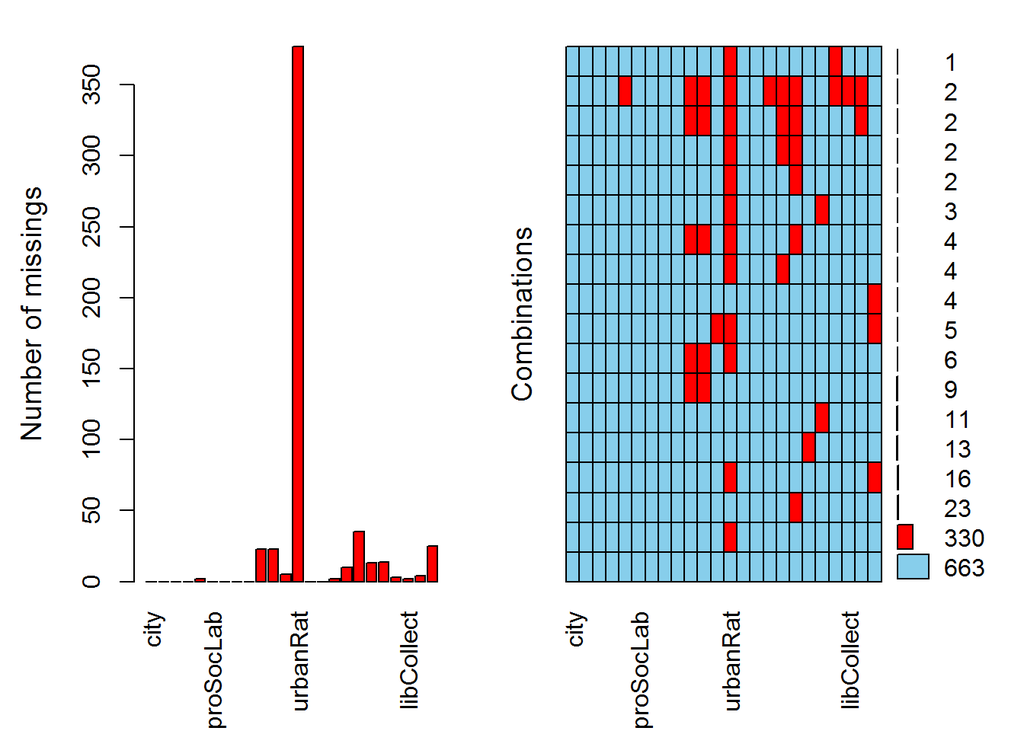

```r
aggr(mydataTemp, prop = F, numbers = T)
```

再次计算每个变量的缺失值数量：

```r
missingdf2 <- as.data.frame(abs(is.na(mydataTemp)))
varmissing2 <- apply(missingdf2, 2, sum)
varmissing2
```

```
##                city                year    realGdpPerCapita       gdpGrowthRate
##                   0                   0                   0                   0
##    InvestOutputRate           proSocLab     pro2industryGdp     pro3industryGdp
##                   2                   0                   0                   0
##  advIndexIndusStruc  ratIndexIndusStruc    nonAgriDevDegree incomeRatUrbanRural
##                   0                  23                  23                   5
##            urbanRat regUrbanUnemployRat proTechEduExpendGdp      amoforeCapUtil
##                 377                   0                   0                   2
##       foreTradeCoef       numCollegeStu   PowConsumpPerGdpL    dischaIndusWaste
##                  10                  35                  13                  14
##       greenCoverRat          libCollect          numHospBed  socSecEmployExpend
##                   3                   2                   4                  25
```

可以看到各个变量的缺失值数目均减少, 只有urbanRat变量含有100个以上的缺失值,而numCollegeStu有35个缺失值, socSecEmployExpend有25,nonAgriDevDegree有23个缺失值,ratIndexIndusStruc有23个缺失值,对于这些,我们需要进行进一步处理。

输出部分结果：

```r
write.csv(mydataTemp, "../output/mydataTemp0923.csv")
```

### 主成分分析

创建完整的数据集：

```r
tempdata <- mydataTemp[which(complete.cases(mydataTemp)) , ]
rownames(tempdata) <- paste(tempdata$city, tempdata$year, sep = "")


#head(tempdata, 10)
#head(mydata2, 10)
compeledata1 <- tempdata[, -c(1, 2)]

#summary(compeledata1)
#dim(compeledata1)

#head(tempdata$city, 10)
head(paste(tempdata$city, tempdata$year, sep = ""), 10)
```

```
##  [1] "上海2018"   "南京市2018" "无锡市2018" "常州市2018" "苏州市2018"
##  [6] "南通市2018" "盐城市2018" "扬州市2018" "镇江市2018" "泰州市2018"
```

中心化标准化数据：

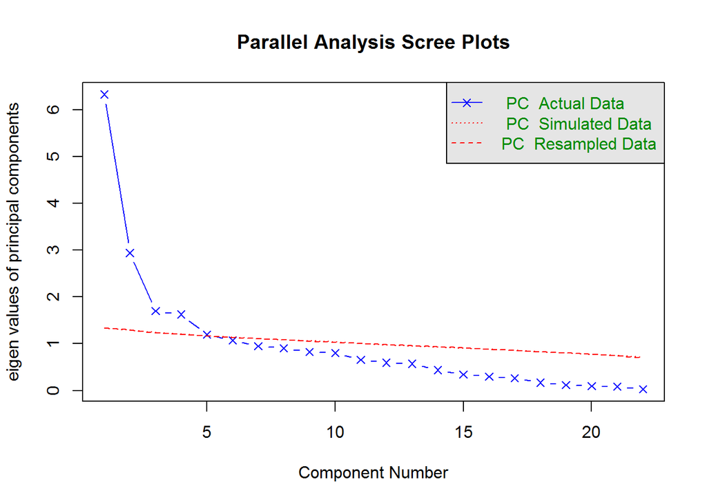

```
## Parallel analysis suggests that the number of factors =  NA  and the number of components =  5
```

```r
scaledata <- scale(compeledata1, center=T,scale=T)
fa.parallel(scaledata, fa = "pc")
```

主成分分析:

```r
pc <- principal(scaledata, nfactors = 5, scores = T)
pc$loadings
```

```
##
## Loadings:
##                     RC1    RC2    RC3    RC4    RC5
## realGdpPerCapita     0.793  0.183  0.395
## gdpGrowthRate       -0.155 -0.380 -0.529 -0.229 -0.172
## InvestOutputRate                   0.286 -0.247  0.287
## proSocLab            0.223         0.652 -0.108  0.220
## pro2industryGdp      0.119 -0.908
## pro3industryGdp      0.509  0.738  0.228  0.202
## advIndexIndusStruc   0.245  0.837  0.110  0.191
## ratIndexIndusStruc  -0.764  0.180 -0.169 -0.282
## nonAgriDevDegree     0.832         0.285  0.225
## incomeRatUrbanRural -0.164        -0.510         0.125
## urbanRat             0.885         0.285
## regUrbanUnemployRat -0.117 -0.108                0.273
## proTechEduExpendGdp -0.284  0.412         0.674
## amoforeCapUtil       0.734  0.342 -0.293 -0.245  0.173
## foreTradeCoef        0.591               -0.145 -0.554
## numCollegeStu        0.211  0.140  0.140         0.725
## PowConsumpPerGdpL    0.104  0.109         0.744
## dischaIndusWaste           -0.507 -0.461  0.215
## greenCoverRat        0.303 -0.323         0.358  0.131
## libCollect           0.673  0.283
## numHospBed           0.390  0.517  0.309  0.334  0.295
## socSecEmployExpend   0.463  0.466 -0.366 -0.162  0.360
##
##                  RC1   RC2   RC3   RC4   RC5
## SS loadings    5.074 3.557 2.038 1.748 1.371
## Proportion Var 0.231 0.162 0.093 0.079 0.062
## Cumulative Var 0.231 0.392 0.485 0.564 0.627
```

主成分分析方法适用于变量之间存在较强相关性的数据,如果原始数据相关性较弱，运用主成分分析后不能起到很好的降维作用,从另一个角度看，主成分不仅可以进行降维，还可以对变量之间的相关性进行检验,我们观察因子载荷矩阵(在一个主成分中，对主成分影响较大的几个变量之间相关性较强,且有时候在理论上具有一些相似的特性)： realGdpPerCapita与nonAgriDevDegree,ratIndexIndusStruc,amoforeCapUtil, foreTradeCoef,libCollect和urbanRat有较强的相关性(RC1) pro2industryGdp与pro3industryGdp,advIndexIndusStruc,socSecEmployExpend和numHospBed有较强的相关性(RC2) gdpGrowthRate与proSocLab, incomeRatUrbanRural和dischaIndusWaste有较强的相关性(RC3) proTechEduExpendGdp与PowConsumpPerGdpL有较强的相关性(RC4) foreTradeCoef与numCollegeStu,PowConsumpPerGdpL有较强的相关性(RC5)

现在我们保存这个载荷矩阵:

```r
write.csv(pc$loadings, "../output/因子载荷矩阵0923.csv")
```

三个城市群进行回归分析：

```r
cityColNum <- which("city" == varname)
mydataTemp2 <- mydataTemp
numlib <- c(0, 41, 77, 110)
cityname2 <- mydataTemp[1:110, cityColNum]

urbanRatNameIndex <- which(colnames(mydataTemp) == "urbanRat")
numCollegeStuNameIndex <- which(colnames(mydataTemp) == "numCollegeStu")
socSecEmployExpendNameIndex <- which(colnames(mydataTemp) == "socSecEmployExpend")
nonAgriDevDegreeNameIndex <- which(colnames(mydataTemp) == "nonAgriDevDegree")
ratIndexIndusStrucNameIndex <- which(colnames(mydataTemp) == "ratIndexIndusStruc")

# realGdpPerCapita与nonAgriDevDegree,ratIndexIndusStruc,amoforeCapUtil,
# foreTradeCoef,libCollect和urbanRat有较强的相关性(RC1)
# pro2industryGdp与pro3industryGdp,advIndexIndusStruc,socSecEmployExpend和numHospBed有较强的相关性(RC2)
# gdpGrowthRate与proSocLab, incomeRatUrbanRural和dischaIndusWaste有较强的相关性(RC3)
# proTechEduExpendGdp与PowConsumpPerGdpL有较强的相关性(RC4)
# foreTradeCoef与numCollegeStu,PowConsumpPerGdpL有较强的相关性(RC5)

# urbanRat变量含有100个以上的缺失值
# numCollegeStu有35个缺失值
# socSecEmployExpend有25个缺失值
# nonAgriDevDegree有23个缺失值
# ratIndexIndusStruc有23个缺失值

for (i in c(1:3)) {
  tempdatalm <- mydataTemp2[which(mydataTemp2$city %in% cityname2[(numlib[i]+1):numlib[i+1]]), ]
  #print((numlib[i]+1):numlib[i+1])
  trainU <- tempdatalm[which(complete.cases(tempdatalm$urbanRat)), ]
  testU <- tempdatalm[which(!complete.cases(tempdatalm$urbanRat)), ]

  if (dim(testU)[1] != 0) {
    print(paste("我执行了1", i, sep = "-"))
    lm1 <- lm(urbanRat ~ amoforeCapUtil + libCollect + foreTradeCoef + realGdpPerCapita,
              data = trainU)
    pre1 <- predict(lm1, testU)
    #print(pre1)

    #赋值
    tempdatalm[which(!complete.cases(tempdatalm$urbanRat)), urbanRatNameIndex] <- pre1
  }


  #socSecEmployExpend与pro2industryGdp,advIndexIndusStruc和amoforeCapUtil
  trainU <- tempdatalm[which(complete.cases(tempdatalm$numCollegeStu)), ]
  testU <- tempdatalm[which(!complete.cases(tempdatalm$numCollegeStu)), ]

  if (dim(testU)[1] != 0) {
    print(paste("我执行了2", i, sep = "-"))
    lm1 <- lm(numCollegeStu ~ PowConsumpPerGdpL + foreTradeCoef,
              data = trainU)
    pre1 <- predict(lm1, testU)
    #print(pre1)
    tempdatalm[which(!complete.cases(tempdatalm$numCollegeStu)), numCollegeStuNameIndex] <- pre1
  }


  trainU <- tempdatalm[which(complete.cases(tempdatalm$socSecEmployExpend)), ]
  testU <- tempdatalm[which(!complete.cases(tempdatalm$socSecEmployExpend)), ]

  if (dim(testU)[1] != 0) {
    print(paste("我执行了3", i, sep = "-"))
    #pro2industryGdp与pro3industryGdp,advIndexIndusStruc,socSecEmployExpend和numHospBed
    lm1 <- lm(formula = socSecEmployExpend ~ numHospBed + advIndexIndusStruc +
                pro2industryGdp + pro3industryGdp,
              data = trainU)

    pre1 <- predict(lm1, testU)
    if (!all(complete.cases(pre1))) {
      print(pre1)
    }
    #print(pre1)
    tempdatalm[which(!complete.cases(tempdatalm$socSecEmployExpend)), socSecEmployExpendNameIndex] <- pre1
  }

  trainU <- tempdatalm[which(complete.cases(tempdatalm$nonAgriDevDegree)), ]
  testU <- tempdatalm[which(!complete.cases(tempdatalm$nonAgriDevDegree)), ]

  if (dim(testU)[1] != 0) {
    print(paste("我执行了4", i, sep = "-"))
    lm1 <- lm(nonAgriDevDegree ~ amoforeCapUtil + libCollect + foreTradeCoef + realGdpPerCapita,
              data = trainU)
    pre1 <- predict(lm1, testU)
    #print(pre1)
    tempdatalm[which(!complete.cases(tempdatalm$nonAgriDevDegree)), nonAgriDevDegreeNameIndex] <- pre1
  }


  trainU <- tempdatalm[which(complete.cases(tempdatalm$ratIndexIndusStruc)), ]
  testU <- tempdatalm[which(!complete.cases(tempdatalm$ratIndexIndusStruc)), ]

  if (dim(testU)[1] != 0) {
    print(paste("我执行了5", i, sep = "-"))
    lm1 <- lm(ratIndexIndusStruc ~ amoforeCapUtil + libCollect + foreTradeCoef + realGdpPerCapita,
              data = trainU)
    pre1 <- predict(lm1, testU)
    #print(pre1)
    #print(pre1)
    tempdatalm[which(!complete.cases(tempdatalm$ratIndexIndusStruc)), ratIndexIndusStrucNameIndex] <- pre1
  }

  mydataTemp2[which(mydataTemp2$city %in% cityname2[(numlib[i]+1):numlib[i+1]]), ] <- tempdatalm
}
```

```
## [1] "我执行了1-1"
## [1] "我执行了4-1"
## [1] "我执行了5-1"
## [1] "我执行了1-2"
## [1] "我执行了2-2"
## [1] "我执行了1-3"
## [1] "我执行了2-3"
## [1] "我执行了3-3"
## [1] "我执行了4-3"
## [1] "我执行了5-3"
```

```r
# [1] "我执行了1-1"
# [1] "我执行了4-1"
# [1] "我执行了5-1"
# [1] "我执行了1-2"
# [1] "我执行了2-2"
# [1] "我执行了1-3"
# [1] "我执行了2-3"
# [1] "我执行了3-3"
# [1] "我执行了4-3"
# [1] "我执行了5-3"
```

绘制缺失值图：

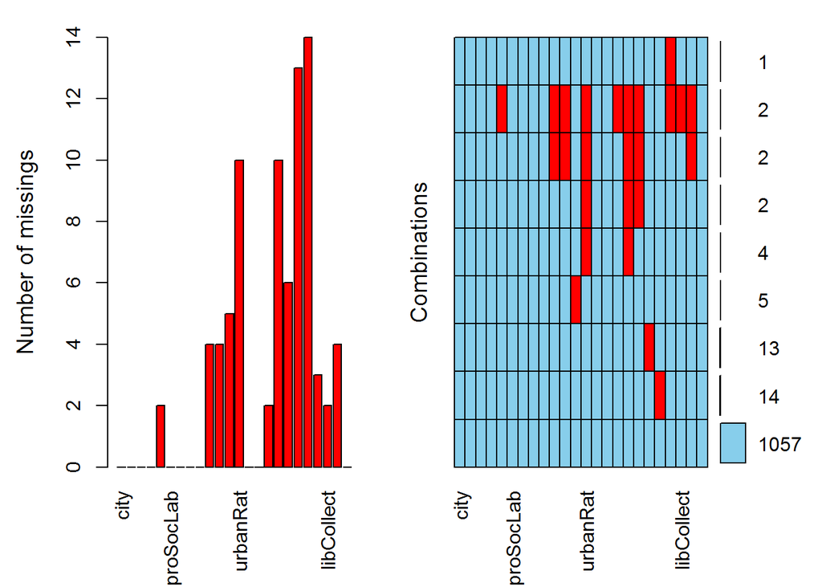

```r
#第三次清理完毕
aggr(mydataTemp2, prop = F, numbers = T)
```

```r
length(which(complete.cases(mydataTemp2))) #1077
```

```
## [1] 1057
```

```r
dim(mydataTemp2)
```

```
## [1] 1100   24
```

```r
missingdf <- as.data.frame(abs(is.na(mydataTemp2)))
varmissing <- apply(missingdf, 2, sum)
varmissing
```

```
##                city                year    realGdpPerCapita       gdpGrowthRate
##                   0                   0                   0                   0
##    InvestOutputRate           proSocLab     pro2industryGdp     pro3industryGdp
##                   2                   0                   0                   0
##  advIndexIndusStruc  ratIndexIndusStruc    nonAgriDevDegree incomeRatUrbanRural
##                   0                   4                   4                   5
##            urbanRat regUrbanUnemployRat proTechEduExpendGdp      amoforeCapUtil
##                  10                   0                   0                   2
##       foreTradeCoef       numCollegeStu   PowConsumpPerGdpL    dischaIndusWaste
##                  10                   6                  13                  14
##       greenCoverRat          libCollect          numHospBed  socSecEmployExpend
##                   3                   2                   4                   0
```

```r
   #             city                year    realGdpPerCapita       gdpGrowthRate    InvestOutputRate
   #                0                   0                   0                   0                   2
   #        proSocLab     pro2industryGdp     pro3industryGdp  advIndexIndusStruc  ratIndexIndusStruc
   #                0                   0                   0                   0                  23
   # nonAgriDevDegree incomeRatUrbanRural            urbanRat regUrbanUnemployRat proTechEduExpendGdp
   #               23                   5                 377                   0                   0
   #   amoforeCapUtil       foreTradeCoef       numCollegeStu   PowConsumpPerGdpL    dischaIndusWaste
   #                2                   6                  35                   1                  10
   #    greenCoverRat          libCollect          numHospBed  socSecEmployExpend
   #                3                   2                   4                  25
```

可以看到进行填补之后, 我们有1057条完整数据, 对于剩下的几个缺失值, 我们单独对其进行处理.现在, 我们直接对剩下的43条数据分别进行均值填补.

首先, 我们查看剩下的缺失值：

```r
mydataTemp2[which(!complete.cases(mydataTemp2)), c(1:2, 5, 10:13, 16:23)]
```

```
##        city year InvestOutputRate ratIndexIndusStruc nonAgriDevDegree
## 28   滁州市 2018        3.0004774         0.18240388      -0.11137704
## 31   六安市 2018        2.0781764         0.28620879      -0.12667603
## 33   蚌埠市 2018        1.4439912         0.44905891      -0.12012271
## 53   武汉市 2018        1.8861701         0.04387930      -0.02271229
## 59   鄂州市 2018        1.0218333         0.33714797      -0.09266338
## 62   黄冈市 2018        8.0567009         0.26128540      -0.16615683
## 63   咸宁市 2018        3.5469098         0.68405839      -0.13519741
## 76   娄底市 2018        3.1358663         0.22728267      -0.09477463
## 101  毕节市 2018        5.4966558         1.00145282      -0.21378631
## 102  铜仁市 2018        4.6379271         0.89843094      -0.22476841
## 105  曲靖市 2018        2.1164784         0.45350299      -0.17398384
## 143  蚌埠市 2017        0.8107814         0.06522941      -0.02913788
## 161  吉安市 2017        0.8263001         0.17852174      -0.13121480
## 203  资阳市 2017        1.7206026         0.50360303      -0.15056135
```

[output cut: 117 more lines]

均值填补:

```r
cityname3 <- unique(mydataTemp2[which(!complete.cases(mydataTemp2)), "city"])
missingdf <- as.data.frame(abs(is.na(mydataTemp2)))
varmissing <- apply(missingdf, 2, sum)
lossingNum <- which(varmissing > 0)
mydataTemp3 <- mydataTemp2
for (itemCity in cityname3) {
  for (itemValue in lossingNum) {
    tempSerise <- mydataTemp3[which(mydataTemp3$city == itemCity), itemValue]
    if (sum(is.na(tempSerise)) > 0) {
      meanTemp <- mean(tempSerise, na.rm = T)
      tempSerise[is.na(tempSerise)] <- meanTemp
      mydataTemp3[which(mydataTemp3$city == itemCity), itemValue] <- tempSerise
    }
  }
}
```

绘制缺失值图:

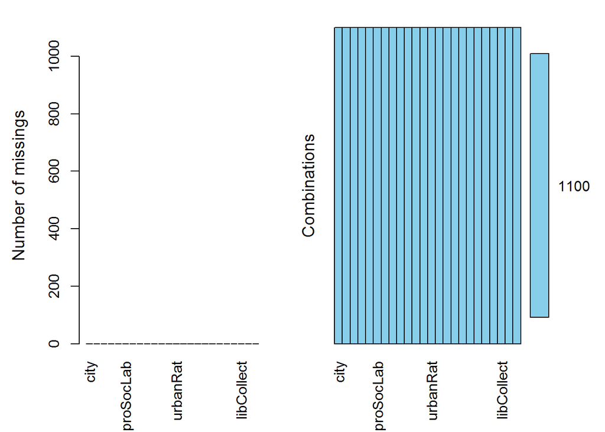

```r
aggr(mydataTemp3, prop = F, numbers = T)
```

可以看到, 缺失值已经全部被填补.

输出填补结果：

```r
write.csv(mydataTemp3, "../output/mydataTemp3.csv")
```